Public spending on elementary and  
secondary education in the US

Amount of USD spent in $1000s per child (inflation-adjusted)

State

1997

2007

2016

2022

Trend

Alabama

4.72

7.00

6.81

9.70

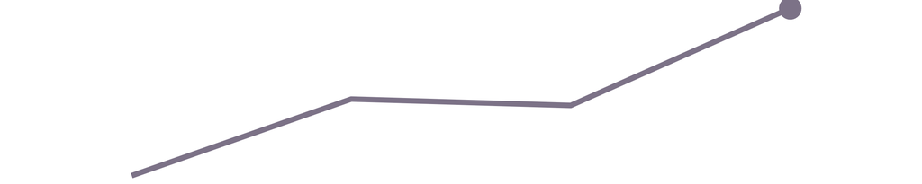

Alaska

9.06

11.36

12.75

17.73

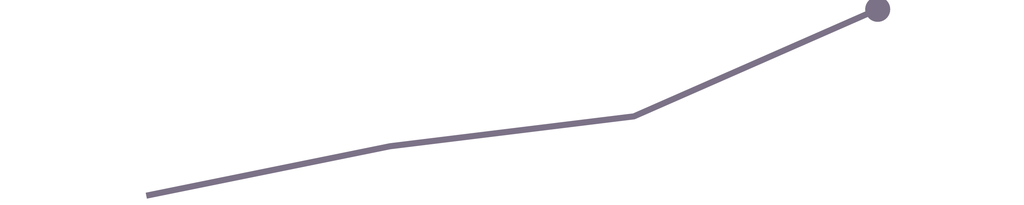

Arizona

4.45

5.53

4.97

8.24

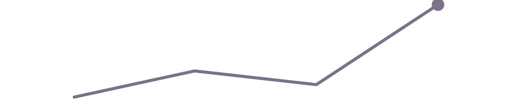

Arkansas

4.67

6.89

7.11

10.14

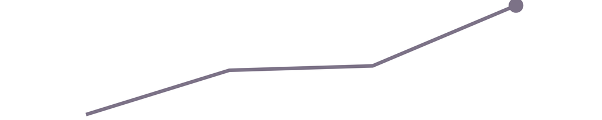

California

5.14

7.97

8.60

12.50

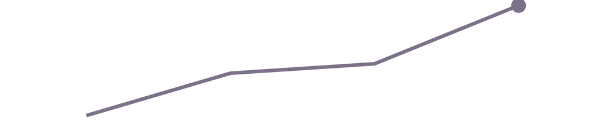

Colorado

5.26

6.78

7.27

10.20

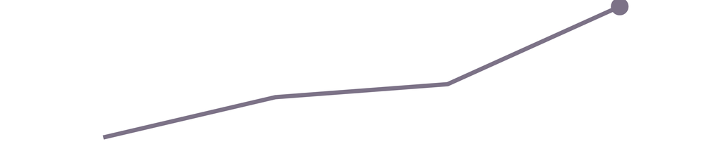

Connecticut

8.04

10.74

12.97

20.64

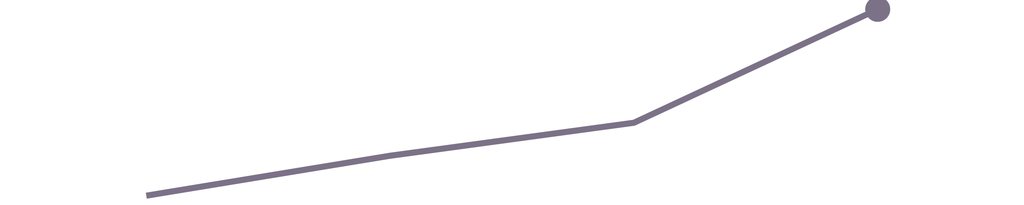

Delaware

6.75

8.55

10.13

15.64

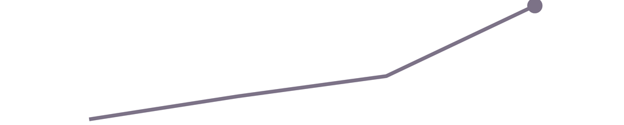

District of Columbia

7.33

15.01

21.19

22.86

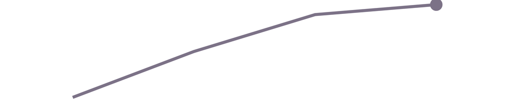

Florida

5.34

7.10

6.60

9.35

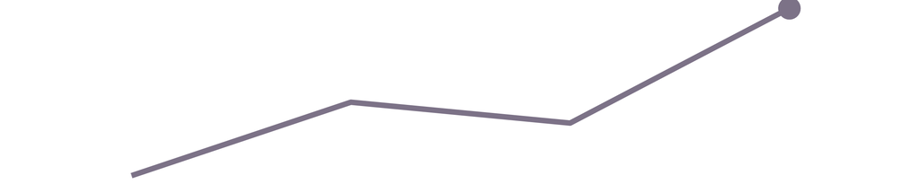

Georgia

5.53

7.52

7.50

10.81

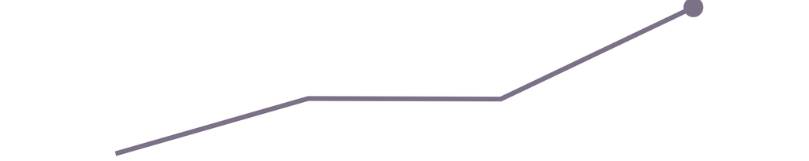

Hawaii

3.88

8.44

6.87

15.24

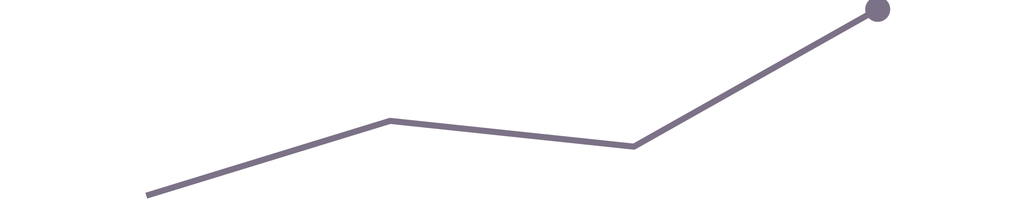

Idaho

4.79

5.35

5.04

7.77

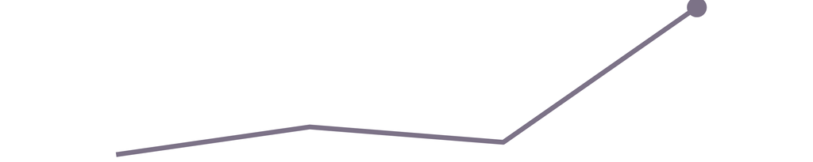

Illinois

5.33

7.75

9.28

15.74

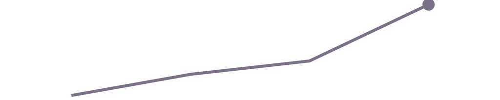

Indiana

5.46

6.92

6.24

10.26

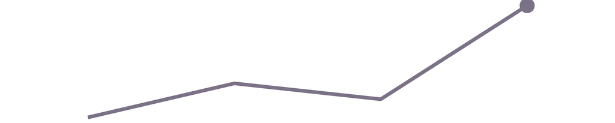

Iowa

5.54

7.34

8.56

11.73

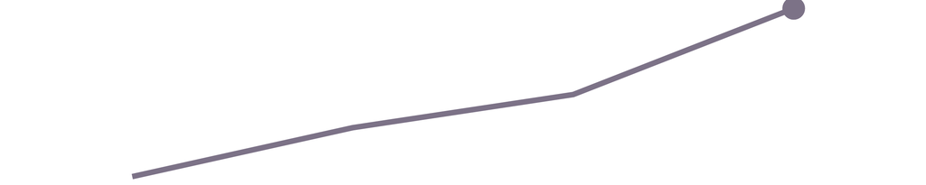

Kansas

5.67

7.19

7.21

11.65

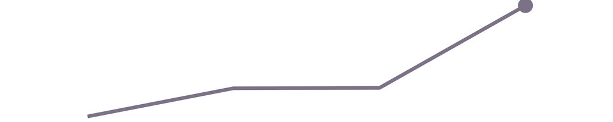

Kentucky

4.84

6.39

7.06

11.11

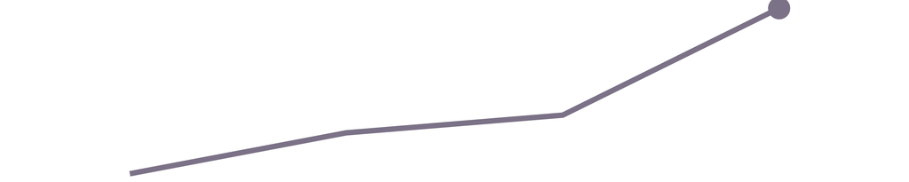

Louisiana

4.78

7.03

7.46

11.45

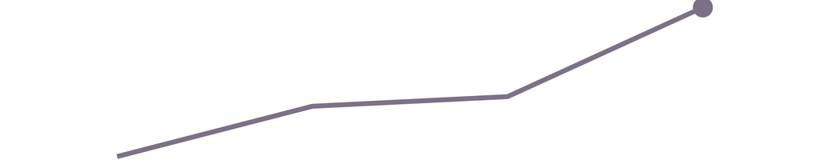

Maine

7.11

9.26

10.14

14.14

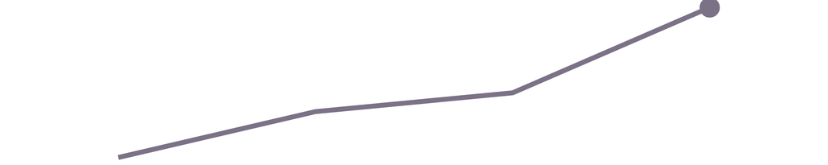

Maryland

6.08

8.76

8.79

14.76

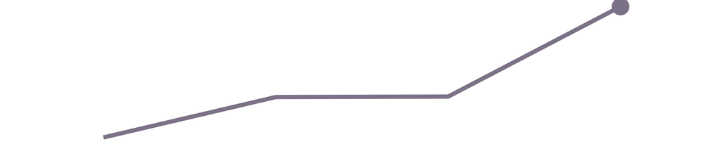

Massachusetts

6.62

9.74

11.39

17.06

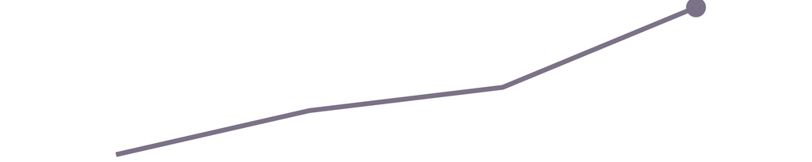

Michigan

6.79

8.79

7.91

12.35

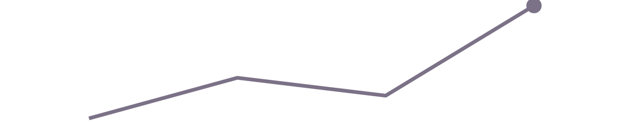

Minnesota

6.68

7.82

8.81

12.97

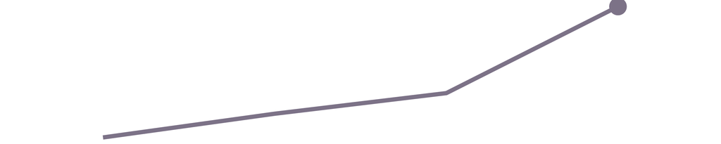

Mississippi

4.09

6.05

6.43

8.94

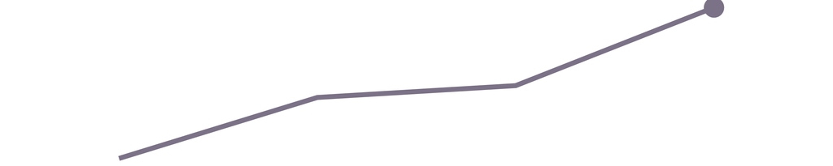

Missouri

5.19

6.89

7.38

10.81

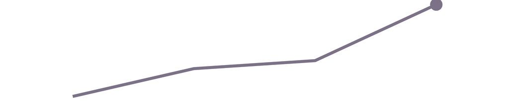

Montana

5.91

7.40

8.00

11.68

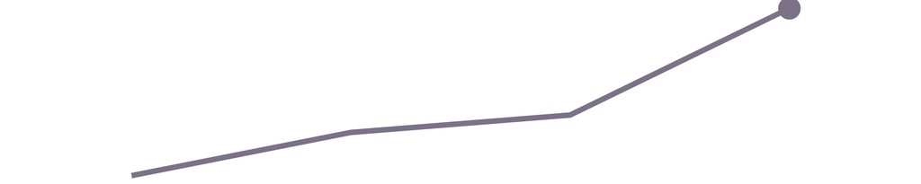

Nebraska

5.65

7.26

8.97

12.49

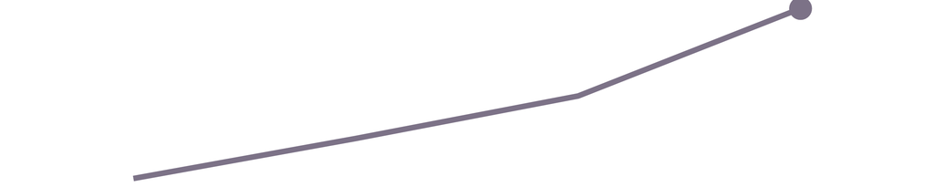

Nevada

5.08

6.55

6.65

9.42

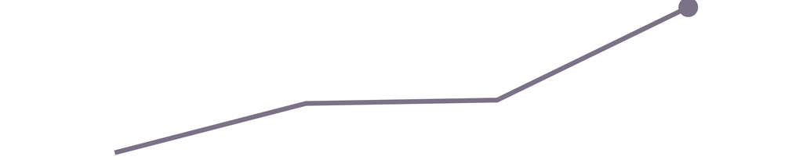

New Hampshire

6.07

9.16

11.79

16.89

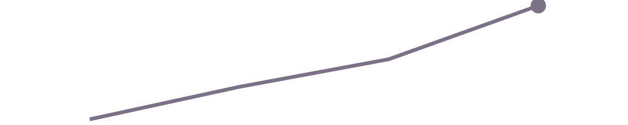

New Jersey

8.67

12.45

13.91

20.02

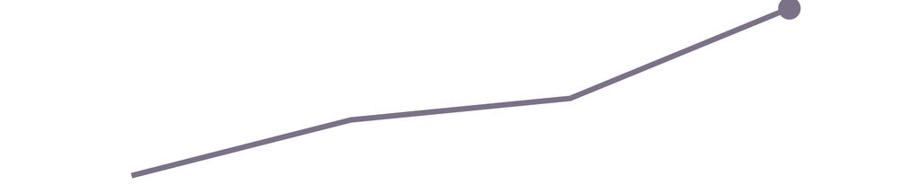

New Mexico

4.75

7.10

7.03

9.58

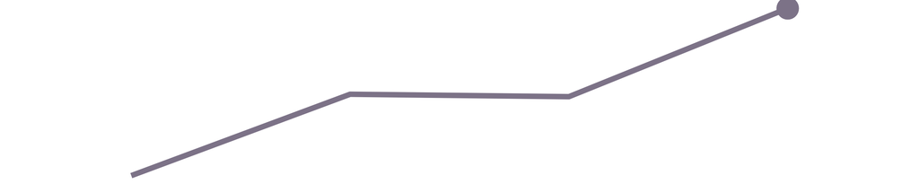

New York

8.46

12.70

15.32

24.04

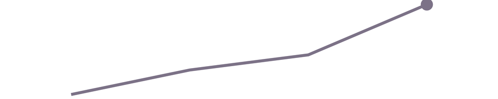

North Carolina

5.07

6.48

6.23

9.38

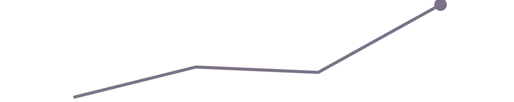

North Dakota

5.05

7.30

9.06

13.76

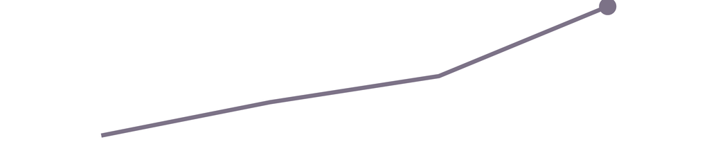

Ohio

5.72

7.94

8.80

13.03

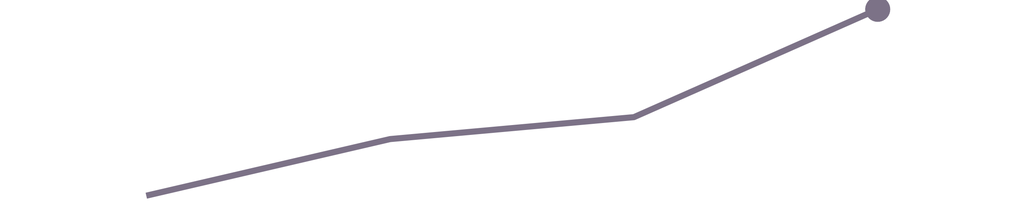

Oklahoma

5.00

6.63

5.87

8.24

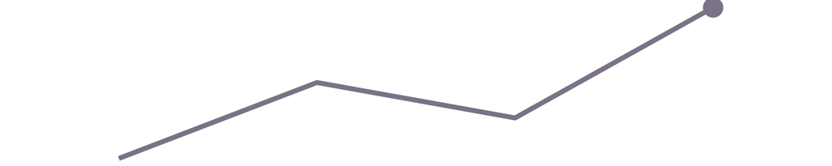

Oregon

6.09

7.42

8.21

11.92

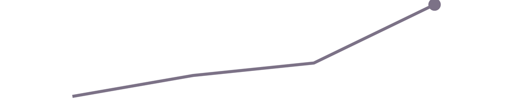

Pennsylvania

6.31

9.05

10.96

16.40

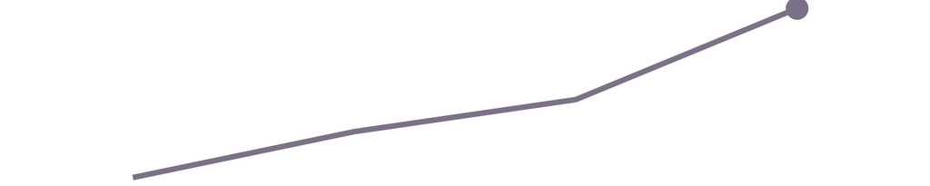

Rhode Island

7.27

10.91

12.24

16.12

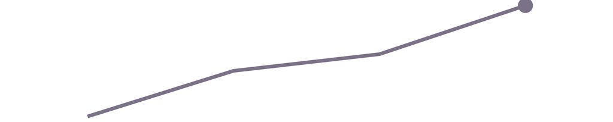

South Carolina

5.03

7.24

7.66

10.86

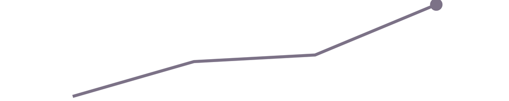

South Dakota

4.79

6.03

6.36

10.07

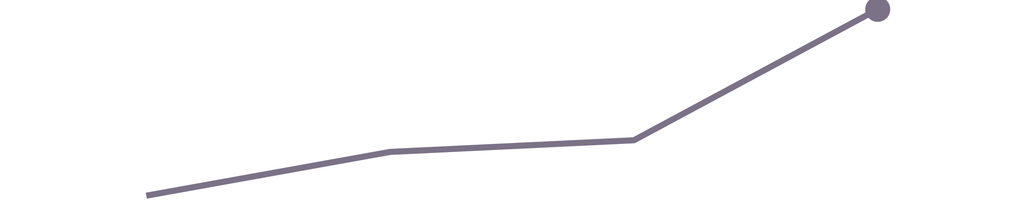

Tennessee

4.62

5.83

6.28

9.54

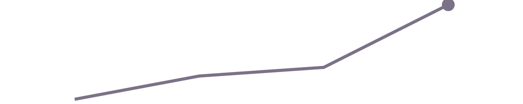

Texas

5.21

6.64

6.76

9.61

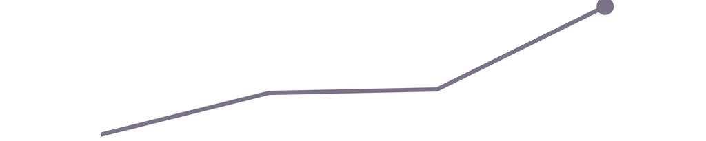

Utah

4.10

4.60

4.89

7.63

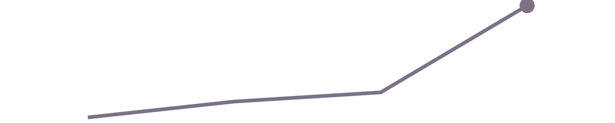

Vermont

6.76

11.58

14.44

9.34

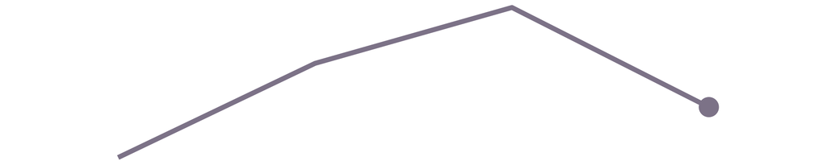

Virginia

5.97

8.75

8.73

12.22

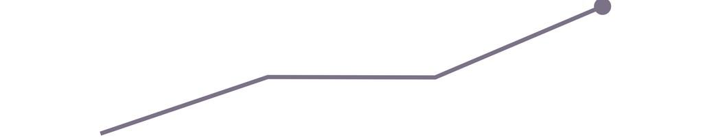

Washington

5.88

6.96

8.61

12.99

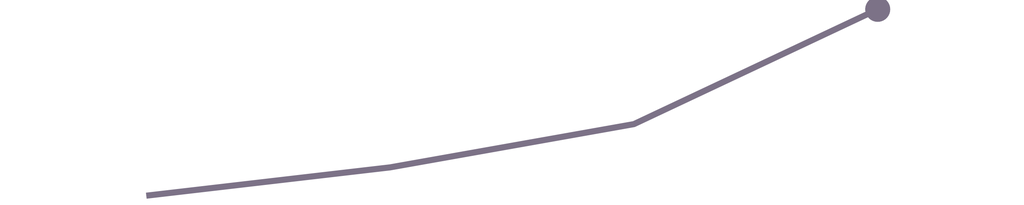

West Virginia

6.68

8.16

8.71

11.33

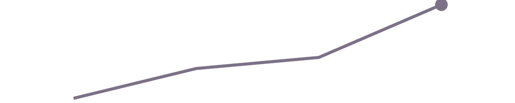

Wisconsin

6.95

8.46

8.53

12.29

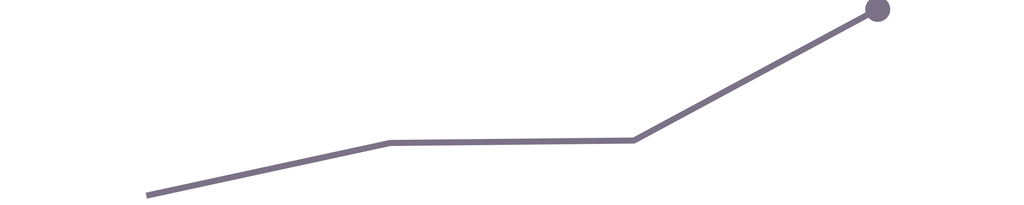

Wyoming

6.97

11.23

12.71

16.22

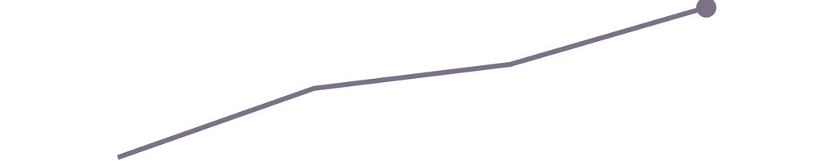

**Data**: Urban Institute | **Table**: @gates_duncan